# Empirical Data Processing: Detecting Epidemics

Anna Maria Langmüller

July 2024

# Overview

This notebook documents the steps taken to detect dengue epidemics at the municipality level using records from **Clarke *et al.* (2024)** (OpenDengue dengue incidence database, https://opendengue.org/data.html, accessed June 12, 2024) and municipality-level processed data from **Siraj *et al.* (2018)** ([Dryad dataset](https://doi.org/10.5061/dryad.83nj1)).

The purpose of this notebook is to provide a transparent and reproducible workflow for detecting epidemic periods in empirical dengue incidence data. For a detailed methodological description, please refer to the accompanying [preprint](https://www.medrxiv.org/content/10.1101/2024.11.28.24318136v2).

# Setup

## Imports

```r
rm(list = ls())
knitr::opts_chunk$set(echo = TRUE)

# Set your working directory
WD <- "./"
setwd(WD)

# Load required libraries
library(plyr)       # Data frame manipulation
library(tidyverse)  # Data wrangling
library(npreg)      # Non-parametric regression (spline smoothing)
```

```r
library(ggplot2)    # Visualization
library(cowplot)    # Plot composition
```

## Functions

```r
# calc_empirical_imax: compute maximum observed incidence for a given epidemic
# Inputs:
#   epidemic_row ... a row from my_epidemics (xmin, xmax, ocha_ID)
#   dengue_data   ... the preprocessed dengue_df data
calc_empirical_imax <- function(epidemic_row, dengue_data) {

  # Subset to the municipality of interest
  mun_data <- subset(dengue_data, ocha_ID == epidemic_row$ocha_ID)

  # Subset to the epidemic period
  period_data <- mun_data[
    mun_data$calendar_start_date >= epidemic_row$xmin &
    mun_data$calendar_start_date <= epidemic_row$xmax,
  ]

  # Return the maximum observed adjusted incidence in this period
  return(max(period_data$dengue_freq, na.rm = TRUE))
}


# plot_epidemics: visualize dengue incidence and detected epidemics for a municipality
# Inputs:
#   epidemics_df   ... detected epidemics (my_epidemics)
#   ocha_id        ... municipality identifier
#   dengue_data    ... preprocessed dengue incidence data
plot_epidemics <- function(epidemics_df, ocha_id, dengue_data) {

  # Filter epidemics and incidence data for the selected municipality
  mun_epidemics <- subset(epidemics_df, ocha_ID == ocha_id)
  mun_counts    <- subset(dengue_data, ocha_ID == ocha_id)

  # Fit smoothing spline to adjusted incidence
  spline_fit <- ss(x = mun_counts$calendar_start_date,
                   y = mun_counts$dengue_freq,
                   lambda = LAMBDA)

  spline_df <- data.frame(
    calendar_start_date = mun_counts$calendar_start_date,
    dengue_freq = fitted(spline_fit)
  )

  # Base plot: bar chart of observed dengue incidence
  g <- ggplot() +
    theme_minimal() +
    geom_bar(data = mun_counts,
             aes(x = calendar_start_date, y = dengue_freq),
             stat = "identity", fill = "white", color = "grey") +
    geom_line(data = spline_df, aes(x = calendar_start_date, y = dengue_freq),
              color = "#de5285") +
    xlab("Date") +
    ylab("Adjusted dengue incidence per week") +
    ggtitle(paste("Municipality:", ocha_id))

  # Overlay epidemic thresholds and periods
  if(nrow(mun_epidemics) > 0){
    g <- g +
      geom_hline(aes(yintercept = thres), data = mun_epidemics, color = "#00cdff") +
      geom_rect(data = mun_epidemics,
                aes(xmin = xmin, xmax = xmax, ymin = -Inf, ymax = Inf),
                fill = "#00cdff", alpha = 0.3)
  }

  return(g)
}
```

## Data Paths

```r
# Data from Siraj et al. (2018)
PATH_SIRAJ_DEMOGRAPHY <- "../data/empirical/Siraj_et_al_2018/municip_aggregate_non_ts.csv"
PATH_SIRAJ_AEDES <- "../data/empirical/Siraj_et_al_2018/municip_Ae_aegypti_weeks_weighted.csv"

# Dengue incidence data from Clarke et al. (2024)
PATH_OD <- "../data/empirical/Clarke_et_al_2024/Highest temporal resolution data_COLOMBIA_20021229_20191231.csv"

# Municipality linkage table
PATH_LINK <- "../data/empirical/IDLinks.txt"

# Global parameters
THRES <- 0.001     # Incidence threshold for epidemic detection
N_THRES <- 30000   # Minimum population size per municipality
CORR_COEF <- 25    # Correction factor for dengue cases
LAMBDA <- 1e-10    # Smoothing parameter for spline regression
```

## Data Import

```r
# Load datasets
dengue <- read.csv(PATH_OD)
pop <- read.csv(PATH_SIRAJ_DEMOGRAPHY)
aedes <- read.csv(PATH_SIRAJ_AEDES)
link <- read.table(PATH_LINK, header = TRUE, sep = "\t")

# Remove non-informative columns (columns with a single unique value)
nonInformative <- sapply(dengue, function(x) length(unique(x)))
dengue <- dengue[, nonInformative > 1]

# Format date columns
dengue$calendar_start_date <- as.Date(dengue$calendar_start_date)
dengue$calendar_end_date <- as.Date(dengue$calendar_end_date)

# Reformat IDs in linkage table
link$ID_ESPACIA <- as.integer(gsub("CO", "", link$ocha_ID))

# Merge datasets using municipality linkage
dengue <- merge(dengue, link[, c("ID_ESPACIA", "full_name", "ocha_ID")], by = "full_name")
pop <- merge(pop, link[, c("ID_ESPACIA", "ocha_ID")], by = "ID_ESPACIA")
aedes <- merge(aedes, link[, c("ID_ESPACIA", "ocha_ID")], by = "ID_ESPACIA")
```

## Data Overview

If we restrict the dataset to municipalities successfully linked between OpenDengue and Siraj *et al.* (2018), we obtain **154,060** weekly dengue incidence records between 2007 and 2019. The highest temporal resolution available is weekly, resulting in 678 reporting periods across 1,009 municipalities.

Each municipality is included in the database only if at least one dengue case was reported for a given week. On average, there are ~153 reporting periods per municipality, with reported weekly incidences ranging between 1 and 839 cases per week per municipality.

```r
# Keep only weekly reporting resolution
if (any(dengue$T_res != "Week")) {
  dengue <- subset(dengue, T_res == "Week")
}

# Summary statistics
nrow(dengue)                                   # Total number of data entries
```

```
## [1] 154060
```

```r
length(unique(dengue$calendar_end_date))       # Number of unique reporting end dates
```

```
## [1] 678
```

```r
length(unique(dengue$calendar_start_date))     # Number of unique reporting start dates
```

```
## [1] 678
```

```r
length(unique(dengue$ocha_ID))              # Number of unique municipalities
```

```
## [1] 1009
```

```r
# Check reporting period lengths
table(as.numeric(as.Date(dengue$calendar_end_date) - as.Date(dengue$calendar_start_date)))
```

```
##
##      5      6
##    324 153736
```

```r
# Number of entries per municipality
municip_summary <- ddply(dengue, .(ocha_ID),
                         summarize, n = length(unique(calendar_start_date)))
summary(municip_summary$n)
```

```
##    Min. 1st Qu.  Median    Mean 3rd Qu.    Max.
##     1.0    23.0    91.0   152.7   224.0   678.0
```

```r
# Maximum reported incidence per municipality
municip_summary <- ddply(dengue, .(ocha_ID),
                         summarize, maxInc = max(dengue_total))
summary(municip_summary$maxInc)
```

```
##    Min. 1st Qu.  Median    Mean 3rd Qu.    Max.
##     1.0     2.0     7.0    17.1    16.0   839.0
```

```r
rm(municip_summary)
```

Because the OpenDengue database only contains records for weeks with **≥1 reported case**, the dataset is “sparse.” For subsequent time-series analysis, we generate a complete panel dataset that includes all weeks for all municipalities in the observation period, filling missing weeks with zeros.

```r
# Extract unique municipality information
all_municipalities <- dengue %>%
  select(full_name, adm_1_name, adm_2_name, FAO_GAUL_code,
         RNE_iso_code, ID_ESPACIA, ocha_ID) %>%
  distinct()

# Extract unique time information (weekly periods)
all_weeks <- dengue %>%
  select(calendar_start_date, calendar_end_date, Year) %>%
  distinct()

# Create full cross-product (municipality × week)
template_df <- expand.grid(
  ocha_ID = all_municipalities$ocha_ID,
  calendar_start_date = all_weeks$calendar_start_date
)

# Merge municipality and time metadata
template_df <- merge(all_municipalities, template_df, by = "ocha_ID")
template_df <- merge(template_df, all_weeks, by = "calendar_start_date")

# Merge with observed dengue data to fill in missing weeks
dengue_df <- merge(
  template_df,
  dengue,
  by = c("full_name", "adm_1_name", "adm_2_name",
         "FAO_GAUL_code", "RNE_iso_code", "ID_ESPACIA",
         "ocha_ID", "calendar_start_date",
         "calendar_end_date", "Year"),
  all.x = TRUE
)

# Fill missing incidence with zero
dengue_df$dengue_total[is.na(dengue_df$dengue_total)] <- 0

# Sort chronologically and by municipality
dengue_df <- dengue_df %>% arrange(ocha_ID, calendar_start_date)

# Sanity checks
table(table(dengue_df$ocha_ID))
```

```
##
##  678
## 1009
```

```r
table(table(dengue_df$calendar_start_date))
```

```
##
## 1009
##  678
```

```r
rm(all_municipalities, all_weeks, template_df)
gc()
```

```
##            used  (Mb) gc trigger  (Mb) limit (Mb) max used  (Mb)
## Ncells  1090056  58.3    4907095 262.1         NA  4909195 262.2
## Vcells 13637860 104.1   53949783 411.7      16384 67413985 514.4
```

# Detecting Epidemics

We focus on municipalities that meet the following criteria:

1. **Population size**: At least 30,000 individuals (to match our individual-based simulations).
2. **Adjusted dengue incidence**: Maximum incidence of at least 0.1% in any reported week.

The adjusted dengue incidence is calculated by multiplying reported cases by a correction factor (`CORR_COEF = 25`) and dividing by municipality population.

Epidemics are defined as periods of ≥4 weeks where the spline-smoothed incidence exceeds the median adjusted incidence for that municipality.

```r
# Merge population data
dengue_df <- merge(
  dengue_df,
  pop[, c("ID_ESPACIA", "Wpop2015")],
  by = "ID_ESPACIA",
  all.x = TRUE
)

# Calculate adjusted dengue proportions
dengue_df$dengue_freq <- dengue_df$dengue_total * CORR_COEF / dengue_df$Wpop2015

# Identify candidate municipalities based on thresholds
candidate_id <- unique(
  dengue_df$ocha_ID[
    dengue_df$dengue_freq >= THRES & dengue_df$Wpop2015 >= N_THRES
  ]
)

# Prepare empty data frame to store epidemic events
my_epidemics <- data.frame(
  xmin = as.Date(character()),
  xmax = as.Date(character()),
  thres = numeric(),
  ocha_ID = character(),
  epidemic_id = character()
)
```

```r
for (i in candidate_id) {

  # Subset data for current municipality
  dengue_iter <- subset(dengue_df, ocha_ID == i)

  # Median incidence (excluding zeros)
  thres_iter <- quantile(dengue_iter$dengue_freq[dengue_iter$dengue_freq > 0], 0.5)

  # Fit smoothing spline
  ss.mod <- ss(x = dengue_iter$calendar_start_date,
               y = dengue_iter$dengue_freq,
               lambda = LAMBDA)

  # Predicted spline values
  ss.fit <- data.frame(
    calendar_start_date = dengue_iter$calendar_start_date,
    dengue_freq = fitted(ss.mod)
  )

  # Identify epidemic weeks (above median threshold)
  ss.fit$epidemic <- ss.fit$dengue_freq > thres_iter

  # Assign epidemic IDs
  ss.fit$epidemic_id <- 0
  epidemic_id <- 1
  row_counter <- 2
  ss.fit$epidemic_id[1] <- ifelse(ss.fit$epidemic[1], epidemic_id, 0)

  while (row_counter <= nrow(ss.fit)) {
    if (ss.fit$epidemic[row_counter]) {
      if (!ss.fit$epidemic[row_counter - 1] && any(ss.fit$epidemic_id > 0)) {
        epidemic_id <- epidemic_id + 1
      }
      ss.fit$epidemic_id[row_counter] <- epidemic_id
    }
    row_counter <- row_counter + 1
  }

  # Extract epidemic ranges
  if (any(ss.fit$epidemic_id > 0)) {
    iter_epidemics <- ddply(
      ss.fit[ss.fit$epidemic_id > 0, ],
      .(epidemic_id),
      summarize,
      xmin = min(calendar_start_date),
      xmax = max(calendar_start_date)
    )

    # Keep only epidemics lasting ≥4 weeks
    iter_epidemics <- subset(iter_epidemics, xmax - xmin > 27)

    if (nrow(iter_epidemics) > 0) {
      iter_epidemics$ocha_ID <- i
      iter_epidemics$epidemic_id <- paste(iter_epidemics$ocha_ID, iter_epidemics$epidemic_id, sep = ".")
      iter_epidemics$thres <- thres_iter

      my_epidemics <- rbind(
        my_epidemics,
        iter_epidemics[, c("xmin", "xmax", "ocha_ID", "epidemic_id", "thres")]
      )
    }
  }
}

# Calculate epidemic duration
my_epidemics$duration <- my_epidemics$xmax - my_epidemics$xmin

# Calculate maximum observed incidence per epidemic
my_epidemics$imax <- sapply(1:nrow(my_epidemics), function(k)
  calc_empirical_imax(my_epidemics[k,], dengue_df)
)

# Filter out epidemics below incidence threshold
my_epidemics <- subset(my_epidemics, imax >= THRES)

# Clean up
rm(iter_epidemics, ss.fit, ss.mod, epidemic_id, i, dengue_iter, row_counter, thres_iter)
gc()
```

```
##            used  (Mb) gc trigger  (Mb) limit (Mb) max used  (Mb)
## Ncells  1107026  59.2    3140541 167.8         NA  4909195 262.2
## Vcells 15054997 114.9   53949783 411.7      16384 67413985 514.4
```

## Characterizing epidemics

### Example plots

The plots below show a random selection of municipalities. For each municipality:

- Grey bars represent the adjusted weekly dengue incidence (cases per population).
- Pink line is a smoothing spline fitted to the time series, highlighting trends in incidence.
- Light-blue rectangles indicate periods detected as epidemic outbreaks.
- Blue horizontal line shows the median incidence threshold used to define epidemics.

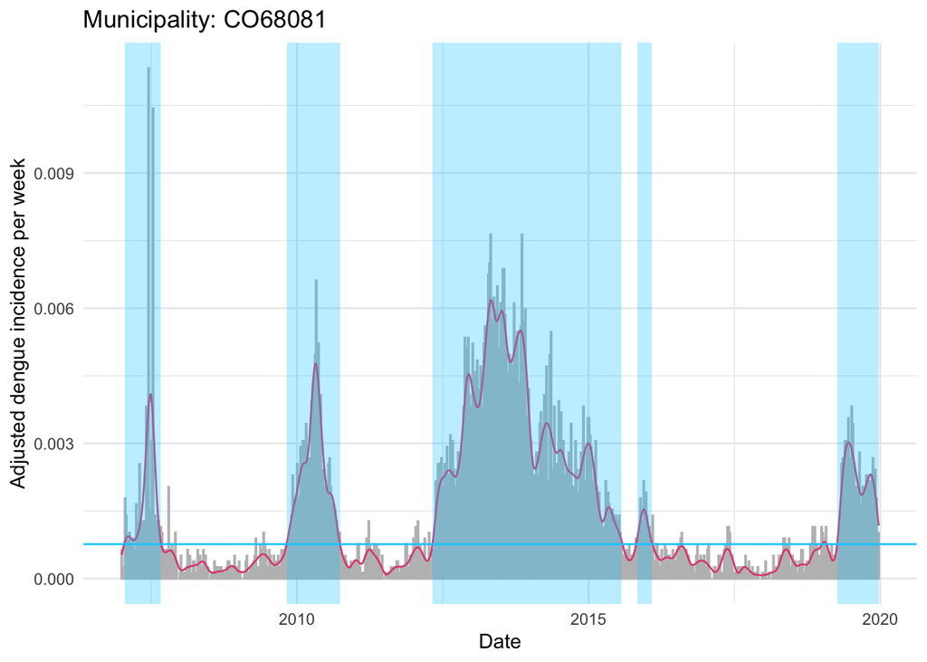

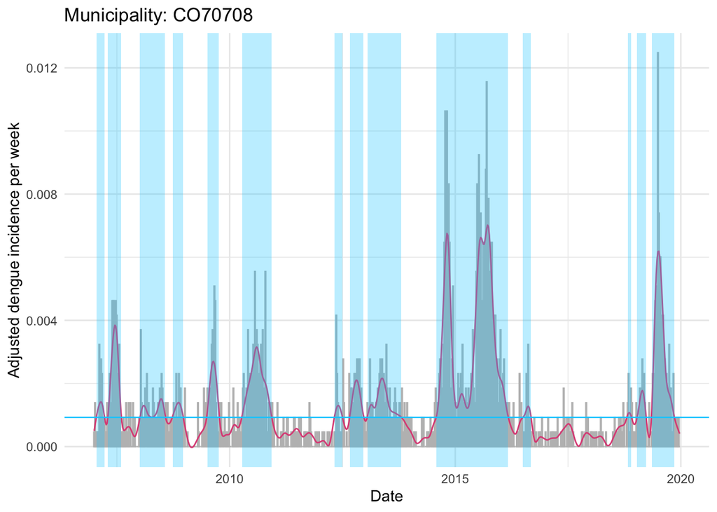

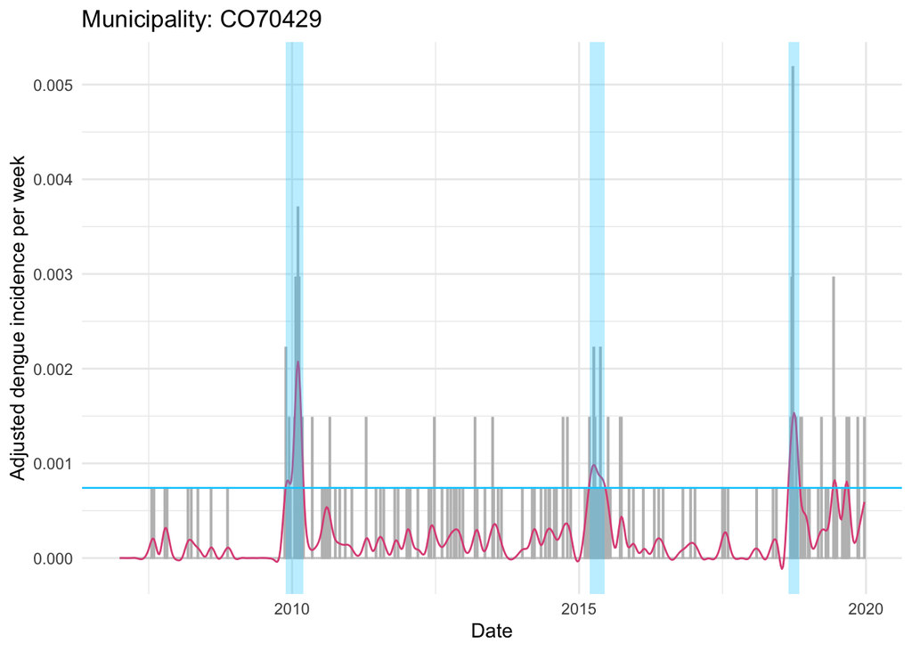

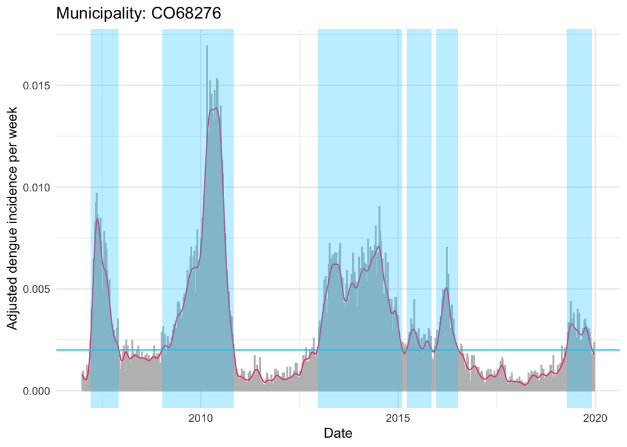

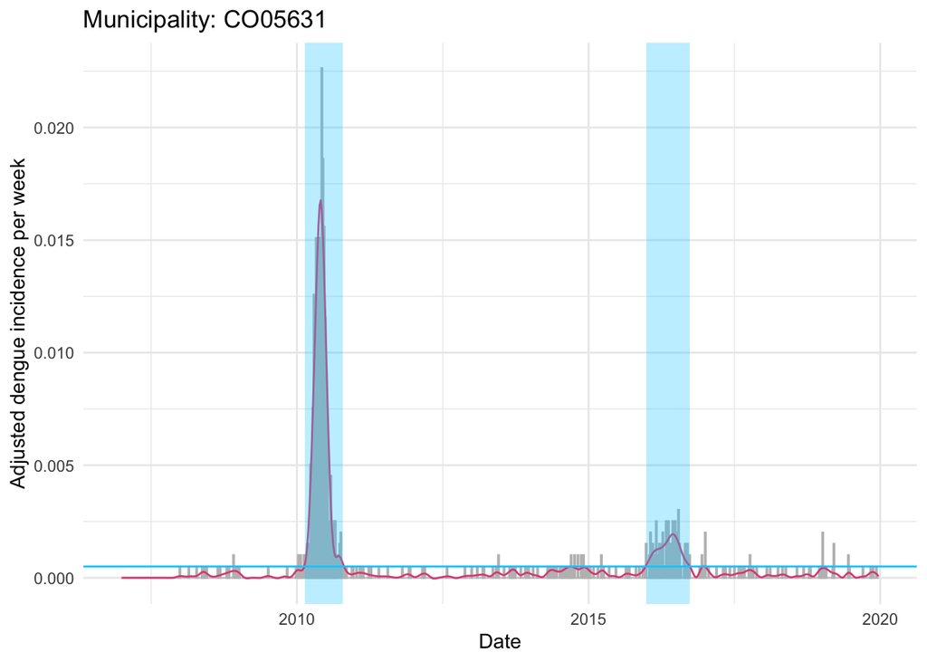

```r
# Randomly select 5 municipalities for example plots
example_ids <- sample(candidate_id, size = 5)

for(id in example_ids){
  print(plot_epidemics(epidemics_df = my_epidemics,
                       ocha_id = id,
                       dengue_data = dengue_df))
}
```

```r
rm(example_ids, id)
```

### Summary statistics of all detected epidemics

```r
# Average number of outbreaks per municipality
avg_outbreaks <- mean(table(my_epidemics$ocha_ID))

# Average duration of epidemics (in days)
avg_duration <- mean(my_epidemics$duration)

# Average maximum adjusted incidence
avg_max_incidence <- mean(my_epidemics$imax)

cat("Average number of outbreaks per municipality:", round(avg_outbreaks,2), "\n")
```

```
## Average number of outbreaks per municipality: 6.34
```

```r
cat("Average duration per outbreak (days):", round(avg_duration,2), "\n")
```

```
## Average duration per outbreak (days): 194.99
```

```r
cat("Average maximum adjusted incidence (%):", round(avg_max_incidence*100,2), "\n")
```

```
## Average maximum adjusted incidence (%): 0.62
```

# Store Epidemics

```r
# Prepare epidemic summary table for storage
epidemic_summary <- data.frame(
  ocha_ID      = my_epidemics$ocha_ID,       # Municipality ID
  epidemic_id  = my_epidemics$epidemic_id,      # Unique epidemic identifier
  start_day    = yday(as.Date(my_epidemics$xmin)), # Day of year for epidemic start
  max_incidence = my_epidemics$imax,            # Maximum incidence during epidemic
  duration_days = as.numeric(my_epidemics$duration) # Epidemic duration in days
)


# Prepare a full version of the epidemic data
epidemic_full <- data.frame(
  xmin        = as.Date(my_epidemics$xmin),
  xmax        = as.Date(my_epidemics$xmax),
  ocha_ID  = my_epidemics$ocha_ID,
  epidemic_id = my_epidemics$epidemic_id,
  thres       = my_epidemics$thres,
  duration    = as.numeric(my_epidemics$duration),
  imax        = my_epidemics$imax
)


# Save both tables as tab-separated text files
write.table(
  epidemic_summary,
  file      = "../data/empirical/OpenDengue_detected_epidemics.txt",
  row.names = FALSE, col.names = TRUE, quote = FALSE, sep = "\t"
)

write.table(
  epidemic_full,
  file      = "../data/empirical/OpenDengue_detected_epidemics_full.txt",
  row.names = FALSE, col.names = TRUE, quote = FALSE, sep = "\t"
)
```